# HomeWork 2

ivan Ojiambo

September 24, 2017

# Exe1-2

The data was seperated by tabs and it has 12 columns and 32561 rows. I have replaced all the missing values with NA

```r
unclean_data <- read.csv( "data.csv",  sep = "\t", strip.white = TRUE, na.strings = c("NA", "?"));
#type of data
str(unclean_data)
```

```
## 'data.frame':    32561 obs. of  12 variables:
##  $ X              : int  0 1 2 3 4 5 6 7 8 9 ...
##  $ age            : int  39 50 38 53 28 37 49 52 31 42 ...
##  $ workclass      : Factor w/ 9 levels "Federal-gov",..: 8 7 4 4 4 4 4 7 4 4 ...
##  $ education      : Factor w/ 16 levels "10th","11th",..: 10 10 12 2 10 13 7 12 13 10 ...
##  $ occupation     : Factor w/ 14 levels "Adm-clerical",..: 1 4 6 6 10 4 8 4 10 4 ...
##  $ capital.gain   : int  2174 0 0 0 0 0 0 0 14084 5178 ...
##  $ capital.loss   : int  0 0 0 0 0 0 0 0 0 0 ...
##  $ native.country : Factor w/ 43 levels "Cambodia","Canada",..: 41 40 41 41 5 41 23 41 41 41 ...
##  $ salaries       : num  43136 46209 28937 33658 34372 ...
##  $ jobsatisfaction: Factor w/ 17 levels "0","1","10","11",..: 1 14 13 13 5 11 14 12 5 12 ...
##  $ male           : int  1 1 1 1 NA NA NA 1 NA 1 ...
##  $ female         : int  NA NA NA NA 1 1 1 NA 1 NA ...
```

I have removed Column X because it does not make sense since the rows are always numbered automatically

```r
unclean_data[,c("X")] <- NULL
```

## 1. Analysing column Age

There are 97 people without age value.

```r
sum(is.na(unclean_data$age))
```

```
## [1] 97
```

The minimum and maximum age in the data is -57 years and 320 years respectively, I have subsituted these values with missing value because its unrealistic to have negative vale as age neither is it realistic to be over 320 years. i have assumed one can not be over 100 years and below 1 year

```r
summary(unclean_data$age)
```

```
##    Min. 1st Qu.  Median    Mean 3rd Qu.    Max.    NA's
##  -57.00   28.00   37.00   38.57   48.00  320.00      97
```

```r
unclean_data$age[unclean_data$age < 1] <- NA
unclean_data$age[unclean_data$age  >100] <- NA
```

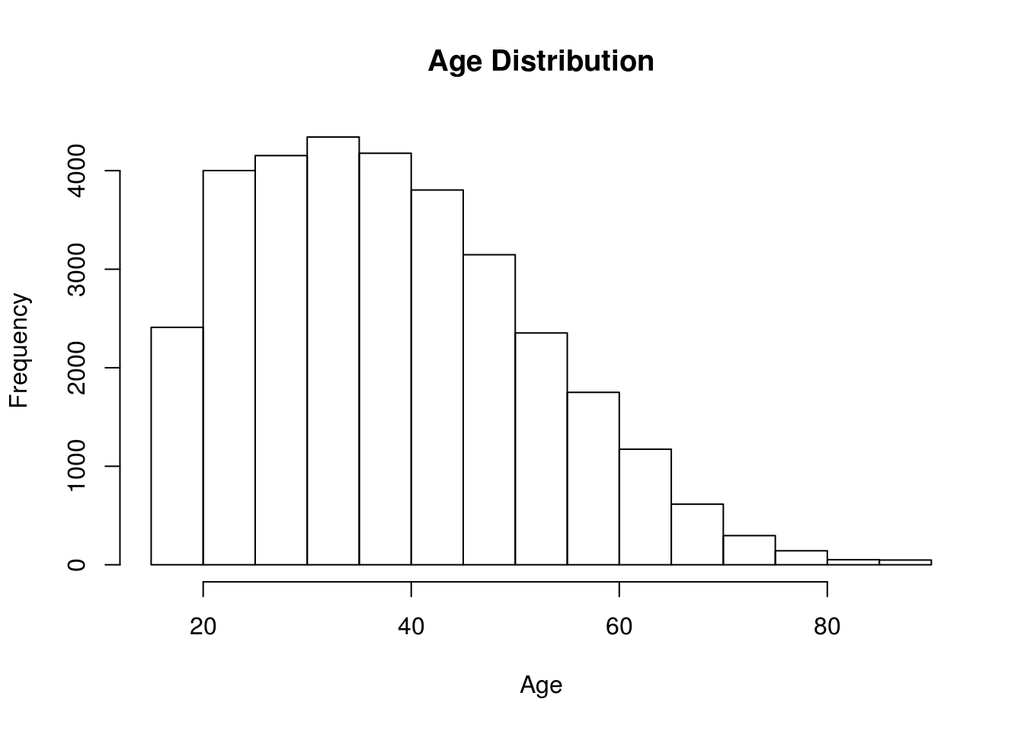

```r
hist(unclean_data$age, xlab = "Age", ylab = "Frequency", main = "Age Distribution")
```

Age is a ratio

## 2. Analysing Workclass Column

There are 1836 people who are not working.

```r
sum(is.na(unclean_data$workclass))
```

```
## [1] 1836
```

There were 10 people who had **privat** as there working class, I decided to add them to **Private** work class. I assumed it was typo since privat was not making sense.

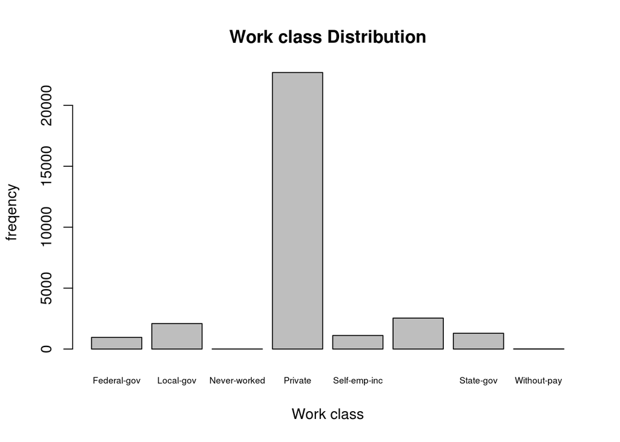

```r
library(plyr)
 revalue(unclean_data$workclass, c("privat" = "Private")) -> unclean_data$workclass

counts <- table(unclean_data$workclass)
barplot(counts,  main = "Work class Distribution", xlab = "Work class", ylab = "freqency", cex.names = 0.6 )
```

Work class is of nominal data type.

## 3. Analysing Column Education

Everyone atlest went to school. ie there is no missing value

```r
library(plyr)
sum(is.na(unclean_data$education))
```

```
## [1] 0
```

```r
counts <-table( unclean_data$education)

unclean_data$education[unclean_data$education =="12th"] <- "1st-12th"
```

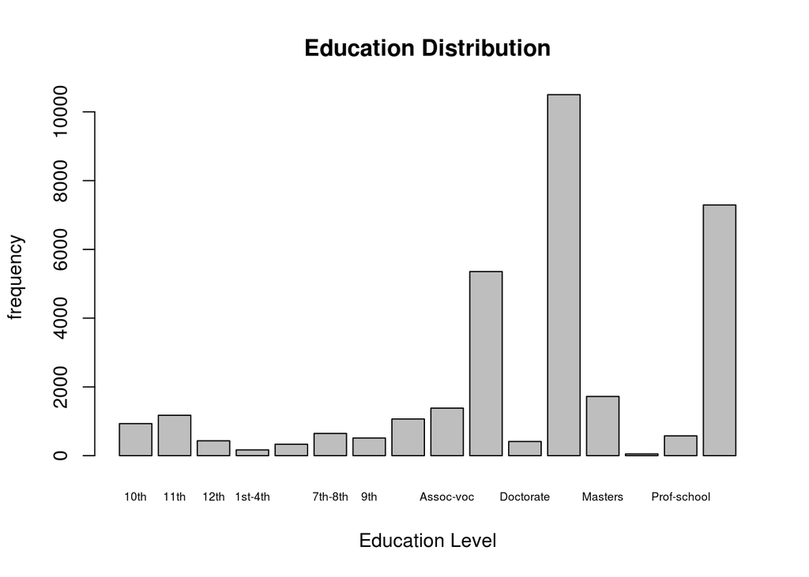

```r
barplot(counts, main = "Education Distribution", xlab = "Education Level", ylab = "frequency", cex.names = 0.6)
```

Education is of ordinal type

## Analysing Attribute occupation

There are 1843 people who do not have occupation

```r
sum(is.na(unclean_data$occupation))
```

```
## [1] 1843
```

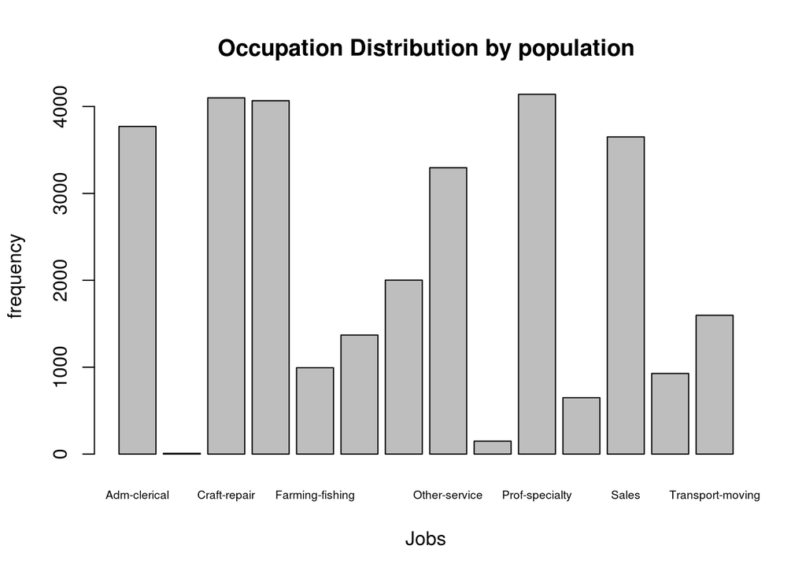

```r
counts <- table(unclean_data$occupation)

barplot(counts,  main = "Occupation Distribution by population", xlab = "Jobs", cex.names = 0.6 ,ylab = "frequency")
```

occupation is of nominal data type.